# Coursework Report

*N* removed NAs: 3

*N* removed <18: 27

[output not shown]

**Main analysis results**

*t*(116) = 10.4, *p* < .001

# Coursework Report

Analysing Data, Spring 2020

# Methods

## Participants

Fifty hundred female participants were initially recruited. However, thirty-six people were removed from the study data due to a restrict age range (from 18 years old to 25 years old). Data was then obtained from a hundred and fourteen participants (*M*<sub>age</sub> = 20.72, *SD*<sub>age</sub> = 1.83). Figure 1 shows the description of participants in red (experimental) condition and white (control) condition.

*Figure 1* Descriptive statistics by categories of age

| Condition | Number of participants | *M*<sub>Age</sub> | *SD*<sub>Age</sub> | *Min*<sub>Age</sub> | *Max*<sub>Age</sub> |
| --- | --- | --- | --- | --- | --- |
| control | 62 | 20.76 | 1.91 | 18 | 25 |
| experimental | 52 | 20.67 | 1.73 | 18 | 24 |

## Design

The study is a replication of Elliot et al’s (2000) study with a research question that if colour, especially red, can influence our perspective of attractiveness. The study used a between-subject design as participants were given a black and white photo of man with either red (n = 52) or white (n = 62) background. The man was a Caucasian man, with brown hair and a plain button-down shirt. He was perceived as moderately attractive. Each photo would be seen for 5 seconds.

To measure their perspectives of the man’s look, participants were asked to rate his attractiveness by three questions: “How attractive do you think this person is?” “How pleasant is this person to look at?” and “If I were to meet the person in this face to face, I would think he is attractive?”. All items were rated on a scale from 1 (not attractive at all) to 9 (extremely attractive) and scores were averaged out. The mean rating of red condition would then be compared to the white condition. The operational hypothesis is to examine whether different background colours of an image of a moderately attractive man could influence the mean ratings of his attractiveness by females. The data was then analysed by t-distribution.

# Results

The result did not support the hypothesis as even though colour had influence on women’s rating of attractiveness, white background tended to make them rate the attractiveness of a guy higher than red background.

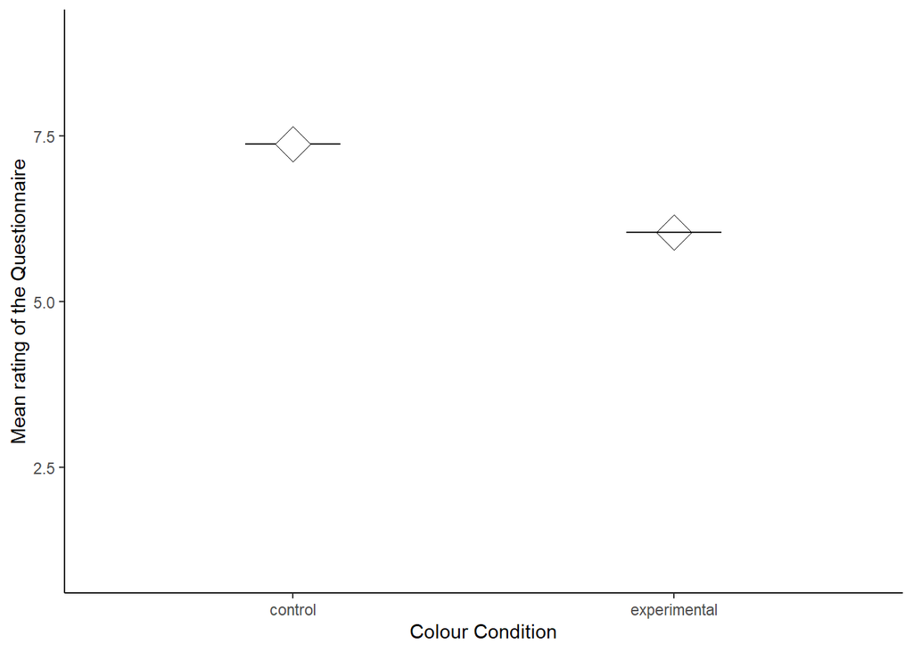

*Figure 2*. Mean Questionnaire Rating by Two Groups

# Discussion

Overall, the study was conducted to replicate Elliot et al (2000)’s study of red effect on attractiveness, whose results showed women tend to be more attracted to men in a red background rather than a white background. We hypothesised that the man would be rated more attractive in a red condition than in a white condition. The participants were divided into either red or white condition. In order to measure their view of attractiveness, all participants were asked to answer three rating-scale questions. The result was contradictory to the hypothesis as a control group was found to rate the man significantly more attractive than the experimental group. This replication did not support Elliot et al’s (2000) research, which manipulated the white and red background in the man’s image and found that women perceived the man significantly more attractive in red background than white background.

As a result, the finding leads us to question if the result of red effect on attractiveness by Elliot and his colleagues is valid. To begin with, Elliot et al (2000)’s study had a relatively small sample size of twenty-one female participants for experiment one. This might then generate a lack of population validity. Additionally, there was already evidence against his previous study as Elliot and Maier (2013)’s replication with a greater sample (n = 144) did not produce a significant difference between red and white effect on attractiveness. Similarly, some studies with a larger sample did not find the significant effect of red colour on attractiveness but compared to other colours, such as, white and black (Peperkoorn, Roberts & Pollet, 2016; Lynn et al, 2016; Hesslinger, Goldbach & Carbon, 2015). Thus, the validity of red effect on attractiveness is proven to be doubtful.

Secondly, it could be argued that different mindsets might be one of the factors explaining why we had different results. In most of cultures, red is seen as passionate love and sexual attractiveness (Wen et al, 2014; Elliot & Neista, 2008), while white is a representative of purity (Aslam, 2006). In this replicate study, participants were asked three questions to determine if they found the man attractive. However, each individual might have different perceptions of attractiveness since some might prefer purity, but others might fancy sexual appearance. This could possibly influence their preference in colour, and thus, lead to the differences in results. We found participants in the replicate study rated white condition significantly higher than red condition. Nevertheless, there are some limitations needed to be addressed, which might explain further the possible reasons causing significantly higher rating for white colour.

When discussing the drawbacks of the study, we need to consider the between-subject design used as participants were only assigned in either the red or the white condition. This might have limited the validity of the result to conclude that red did not have effect on attractiveness. For example, some women who rated the man in white background highly attractive, perhaps might rate him even more attractive in red background, but it is uncertain as we did not take consideration of each individual’s view on both red and white condition. This problem refers to individual differences, which means each individual has psychological characteristics that can be differentiated from others (Whitsett & Shoda, 2014). More specifically for this study, participants might have different perspectives in attractiveness. Peperkoorn, Roberts & Pollet’s (2016) study also used between-subject design and found out that red colour had no significant effect on attractiveness.

Another limitation that we might need to address is the sample in this study. Although the sample size was relatively high at a hundred and fourteen female participants, they were divided into two groups, which made the number of people in each condition greatly reduced. This might mean there was not a large enough sample in this study. Additionally, the two conditions did not have an equal number of participants (fifty-two people in the red condition and sixty-two people in the white condition). This then questions the population validity, which suggests to what extent that the sample’s result can generalise the population of the study (Kukull & Ganguli, 2012). Therefore, it might be hard to conclude that white background had effect on attractiveness rather than red background.

It is undoubtfully interesting for researchers to study about colour effect on human’s behaviour, especially how it can influence our perspective of attractiveness (Elliot et al, 2000; Elliot & Neista, 2008). The study found that white colour led to high rating rather than red. This was contradictory to many previous studies as they found red colour led to higher attractiveness rating compared to white (Elliot et al, 2000; Roberts et al., 2010). This might suggest further research need to compare white and red colour in different contexts, such as shirt colours, jewellery, and accessories. This can assess the consistency of the red and white effect on attractiveness. Additionally, red colour might have different meanings to different ethnic (Elliot & Maier, 2012), which perhaps can explain why studies in colour effect have had a variety of findings. For example, in Chinese culture, apart from representing love, red is mainly about the luckiness and money (Neat et al, 2002; Aslam, 2006). While Western culture, such as America, it symbolises love and attractiveness. Interestingly, some traditional cultures (Slavs and Anglo-Saxon), red also implies anger, fear and jealousy (Aslam, 2006). Further research might consider measuring the cultural differences of red effect. This can be done by conducting a replicate with larger sample size, including a various range of ethnic, for example, cross-cultural design.

Overall, the findings of our study did not consistent with Elliot et al (2000) as there was no red effect on attractiveness found but rather white made an influence on participants. However, the study still has some limitations in terms of sample and design used. Hence, there is a concern that this might not be enough to conclude colour, especially red, has no impact on attractiveness. In the future, more studies might need to be done so that we can improve the reliability and validity. Peperkoorn, Roberts & Pollet’s (2016) study also suggested a further research in red effect on different areas, such as advertising (Aslam, 2006) and politics (Kramer, 2016). This may then help we explore a broader view of red effect on our behaviours and perspectives.

# References

Aslam, M. M. (2006). Are you selling the right colour? A cross cultural review of colour as a marketing cue. *Journal of Marketing Communications*, 12, 15–30. http://doi.org/10.1080/13527260500247827

Elliot, A. J., & Maier, M. A. (2012). *Color-in-context theory. In A. Devine & P. Plant (Ed.), Advances in experimental social psychology*, 45. 63–125. New York, NY: Academic Press.

Elliot, A. J., & Maier, M. A. (2013). The red-attractiveness effect, applying the Ioannidis and Trikalinos (2007b) test and the broader scientific context: A reply to Francis (2013). *Journal of Experimental Psychology: General*, 142, 297–300. http://doi.org/10.1037/a0029592

Elliot, A. J., & Niesta, D. (2008). Romantic red: Red enhances men’s attraction to women. *Journal of Personality and Social Psychology*, 95, 1150–1164. http://doi.org/10.1037/0022-3514.95.5.1150

Hesslinger, V., Goldbach, L., & Carbon, C. (2015). Men in red: A reexamination of the red-attractiveness effect. *Psychonomic Bulletin & Review*, 22(4), 1142-1148. https://doi.org/10.3758/s13423-015-0866-8

Kramer, R. S. S. (2016). The red power(less) tie: Perceptions of political leaders wearing red. *Evolutionary Psychology*, 14, 1–8. http://doi.org/10.1177/1474704916651634

Kukull, W., & Ganguli, M. (2012). Generalizability: The trees, the forest, and the low-hanging fruit. Neurology, 78(23), 1886-1891. https://doi.org/10.1212/wnl.0b013e318258f812

Lynn, M., Giebelhausen, M., Garcia, S., Li, Y., & Patumanon, I. (2016). Clothing color and tipping: An attempted replication and extension. *Journal of Hospitality & Tourism Research, 40*, 516–524. http://doi.org/10.1177/1096348013504001

Neal, C. M., Quester, P. G. & Hawkins, D. I. (2002). *Consumer Behaviour: Implications for Marketing Strategy*. 3rd edn (Roseville, NSW: McGraw-Hill).

Peperkoorn, L., Roberts, S., & Pollet, T. (2016). Revisiting the Red Effect on Attractiveness and Sexual Receptivity. *Evolutionary Psychology*, 14(4), 147470491667384. https://doi.org/10.1177/1474704916673841

Roberts, S., Owen, R., & Havlicek, J. (2010). Distinguishing between Perceiver and Wearer Effects in Clothing Color-Associated Attributions. *Evolutionary Psychology*, 8(3), 147470491000800. https://doi.org/10.1177/147470491000800304

Wen, F., Zuo, B., Wu, Y., Sun, S., & Liu, K. (2014). Red is Romantic, but Only for Feminine Females: Sexual Dimorphism Moderates Red Effect on Sexual Attraction. *Evolutionary Psychology*, 12(4), 147470491401200. https://doi.org/10.1177/147470491401200404

Whitsett, D., & Shoda, Y. (2014). An approach to test for individual differences in the effects of situations without using moderator variables. Journal Of Experimental Social Psychology, 50, 94-104. https://doi.org/10.1016/j.jesp.2013.08.008